# TS_HW2_Liang_Gong

2025-01-23

```r
library(fpp3)
library(dplyr)
```

**9.2 A classic example of a non-stationary series are stock prices. Plot the daily closing prices for Amazon stock (contained in gafa_stock), along with the ACF and PACF. Explain how each plot shows that the series is non-stationary and should be differenced.**

```r
head(gafa_stock)
```

```
## # A tsibble: 6 x 8 [!]
## # Key:       Symbol [1]
##   Symbol Date        Open  High   Low Close Adj_Close    Volume
##   <chr>  <date>     <dbl> <dbl> <dbl> <dbl>     <dbl>     <dbl>
## 1 AAPL   2014-01-02  79.4  79.6  78.9  79.0      67.0  58671200
## 2 AAPL   2014-01-03  79.0  79.1  77.2  77.3      65.5  98116900
## 3 AAPL   2014-01-06  76.8  78.1  76.2  77.7      65.9 103152700
## 4 AAPL   2014-01-07  77.8  78.0  76.8  77.1      65.4  79302300
## 5 AAPL   2014-01-08  77.0  77.9  77.0  77.6      65.8  64632400
## 6 AAPL   2014-01-09  78.1  78.1  76.5  76.6      65.0  69787200
```

```r
# Extract Amazon stock data
amazon <- gafa_stock %>%
  filter(Symbol == "AMZN")

# View the first few rows of the dataset
head(amazon)
```

```
## # A tsibble: 6 x 8 [!]
## # Key:       Symbol [1]
##   Symbol Date        Open  High   Low Close Adj_Close  Volume
##   <chr>  <date>     <dbl> <dbl> <dbl> <dbl>     <dbl>   <dbl>
## 1 AMZN   2014-01-02  399.  399.  394.  398.      398. 2137800
## 2 AMZN   2014-01-03  398.  403.  396.  396.      396. 2210200
## 3 AMZN   2014-01-06  396.  397   388.  394.      394. 3170600
## 4 AMZN   2014-01-07  395.  398.  394.  398.      398. 1916000
## 5 AMZN   2014-01-08  398.  403   396.  402.      402. 2316500
## 6 AMZN   2014-01-09  404.  407.  398.  401.      401. 2103000
```

The plot shows that the series is non-stationary because the mean and variance are not constant over time. Specifically, the series exhibits:

1. **Trend:** The upward movement in prices from 2014 to late 2018 indicates a clear trend.
2. **Changing Variance:** The fluctuations (volatility) in the data increase as prices rise, which is inconsistent with stationarity.

To make the series stationary, it should be differenced to remove the trend and stabilize the variance.

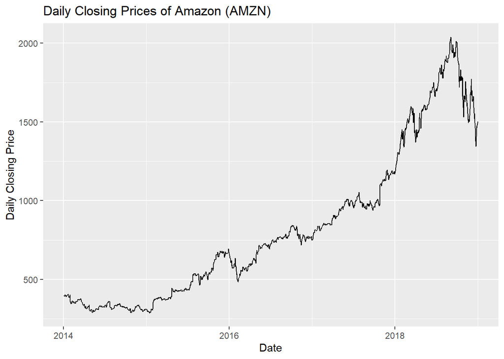

```r
# Plot the daily closing prices for Amazon
amazon %>%
  autoplot(Close) +
  ggtitle("Daily Closing Prices of Amazon (AMZN)") +
  xlab("Date") +
  ylab("Daily Closing Price")
```

-ACF of Amazon Daily Closing Prices (autocorrelation function): The ACF plot shows that the series is non-stationary because the autocorrelation values decay very slowly and remain significant at many lags, instead of dropping off quickly. This persistent correlation indicates a strong trend or non-stationarity in the data. Differencing the series can help remove this trend and stabilize the autocorrelations.

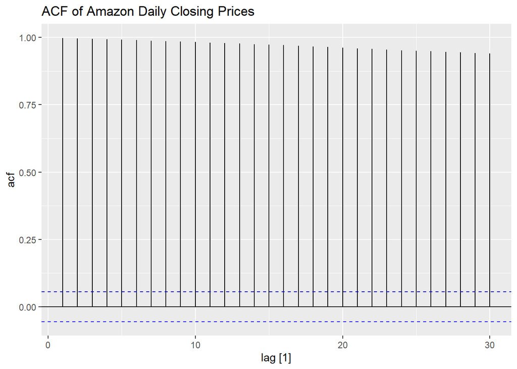

```r
# ACF plot
amazon %>%
  ACF(Close) %>%
  autoplot() +
  ggtitle("ACF of Amazon Daily Closing Prices")
```

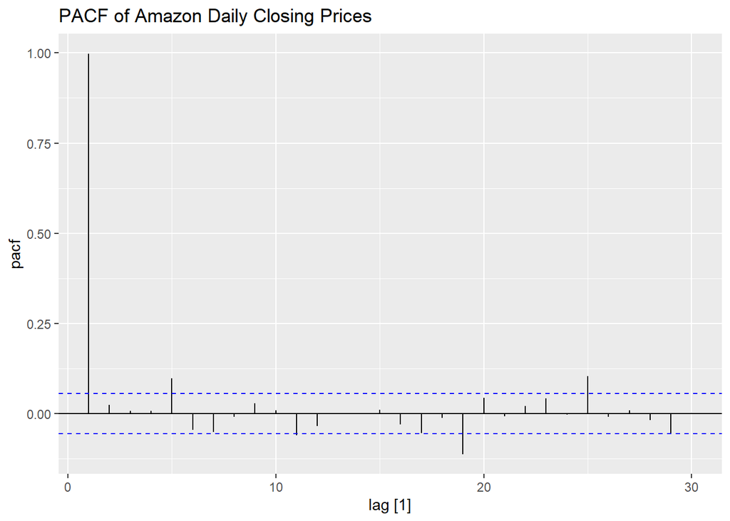

```r
# PACF plot
amazon %>%
  PACF(Close) %>%
  autoplot() +
  ggtitle("PACF of Amazon Daily Closing Prices")
```

Differencing transforms a time series by computing differences between consecutive observations to stabilize the mean and remove trends or seasonality. This helps achieve stationarity, making the series suitable for time series models like ARIMA. Stationarity can be verified after differencing using ACF, PACF plots, or tests like the Augmented Dickey-Fuller test.Below is how the plots look after differencing.

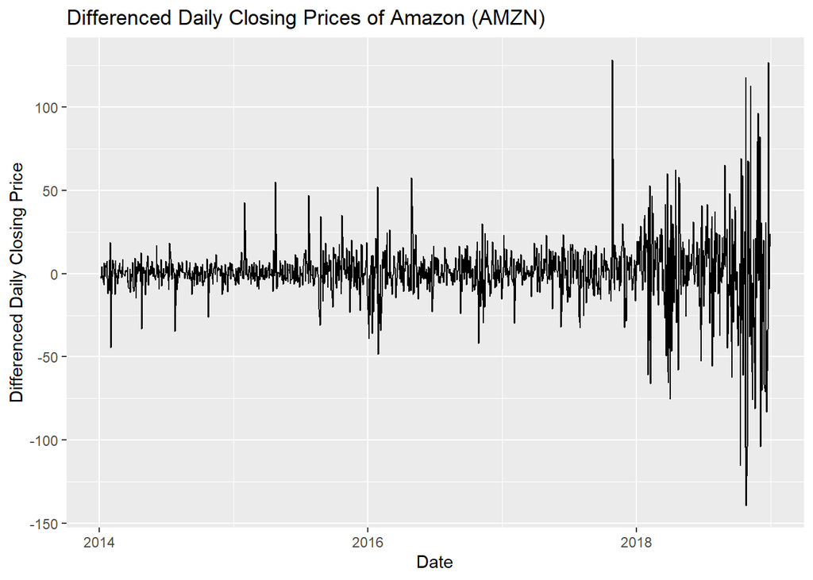

```r
# Difference the data to make it stationary
amazon_diff <- amazon %>%
  mutate(Close_diff = difference(Close))

# Plot the differenced data
amazon_diff %>%
  autoplot(Close_diff) +
  ggtitle("Differenced Daily Closing Prices of Amazon (AMZN)") +
  xlab("Date") +
  ylab("Differenced Daily Closing Price")
```

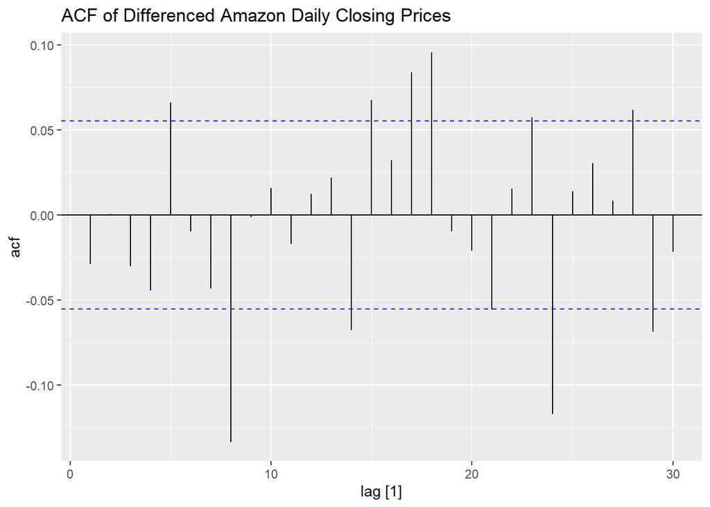

```r
# ACF and PACF for differenced series
amazon_diff %>%
  ACF(Close_diff, na.action = na.pass) %>%
  autoplot() +
  ggtitle("ACF of Differenced Amazon Daily Closing Prices")
```

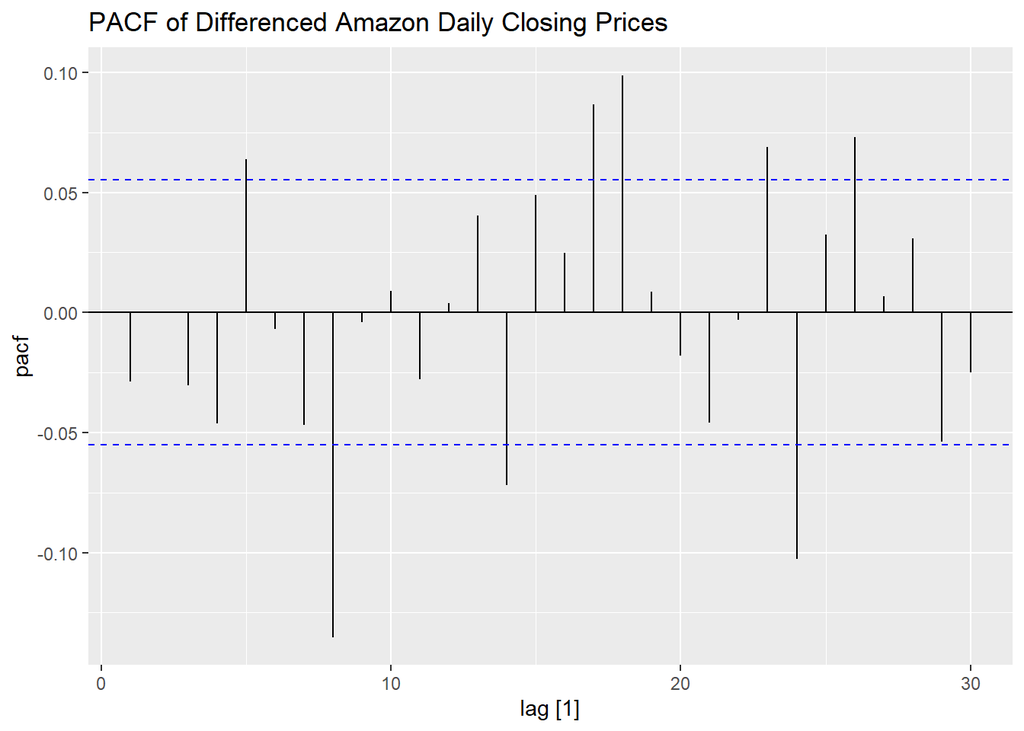

```r
amazon_diff %>%
  PACF(Close_diff, na.action = na.pass) %>%
  autoplot() +
  ggtitle("PACF of Differenced Amazon Daily Closing Prices")
```

**9.7 Consider aus_airpassengers, the total number of passengers (in millions) from Australian air carriers for the period 1970-2011.**